# Structural holes, Structural equivalence, and some more visualization

SNA Week 8

# Measuring Structural holes

# More **constrained** nodes ($C_i$) and edges ($c_{ij}$) span fewer structural holes

$$C_i = \sum_j c_{ij} \text{ for } i \neq j \\
c_{ij} = (p_{ij} + \sum_q p_{iq}p_{qj})^2 \text{ for } q \neq i \neq j \\
p_{ij} = \frac{z_{ij}}{\sum_q z_{iq}}$$

- $p$ is the proportion of i’s network time and energy invested in contact j
- $z_{ij}$ measures the zero to one strength of connection between contacts i and j
- undefined for isolates, can be set to the maximum

# Node Constraint is the sum of three variables: **C-size**, C-density , & **C-hierarchy**

- **C-size** ($\sum_j (p_{ij})^2$) is a Herfindahl index measuring extent to which $i$’s relations are concentrated in a single contact
- C-density ($2\sum_j p_{ij}(\sum_q p_{iq}p_{qi})$) is an interaction between strong ties and density. Increases when $i$’s strongest ties go to nodes who are also strongly tied to $i$’s other associates
- **C-hierarchy** ($\sum_j (\sum_q p_{iq}p_{qj})^2$) increases as $i$’s associates concentrate their relations with one central contact

# As commonly used, **Constraint** focuses on the egonet

In contrast, betweenness focuses on entire network, but does not differentiate between paths between direct associates and paths connecting indirectly connected nodes

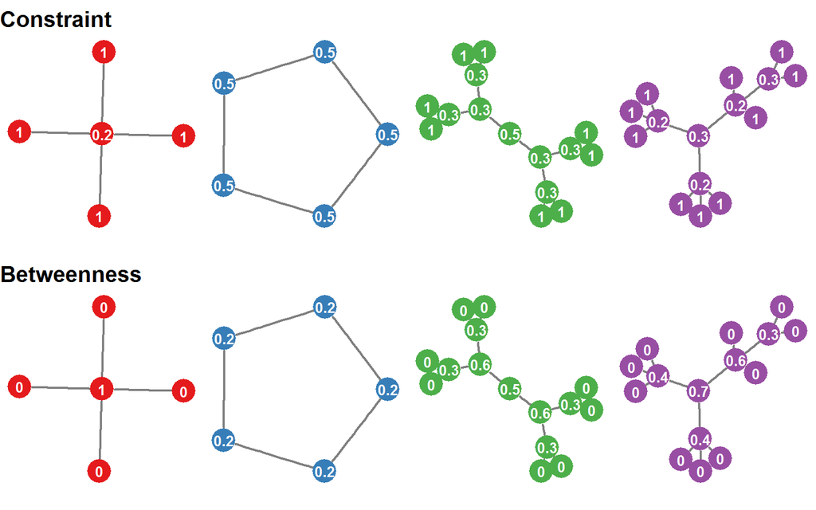

```r
round(correlations, 2)
```

```
## [1] -1.00    NA -0.86 -0.92
```

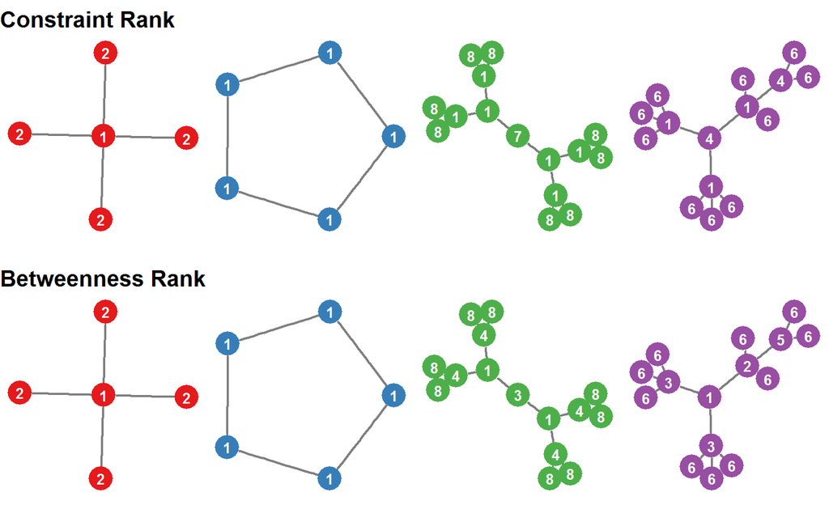

```r
round(correlations, 2)
```

[output not shown]

# Measuring Structural Equivalence

The following examples rely on cleaned data from `Create FA Net.R` on Blackboard

The data explore the two-mode legislator-topic proposal network in 2011 Florida

You may use the data to replicate these results, but you must seek permission to use the data for your own research

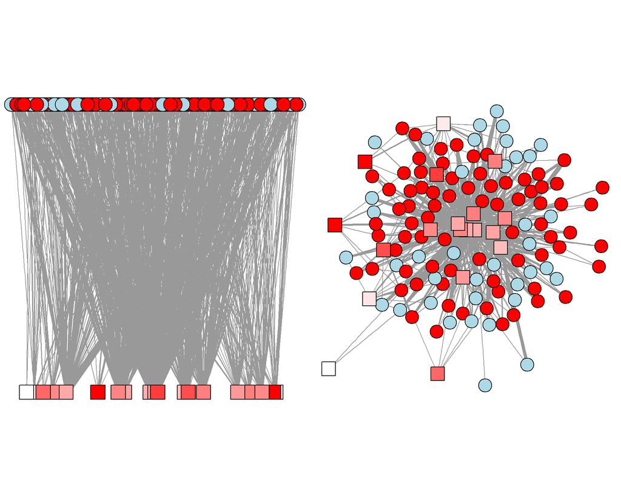

# Measures of structural equivalence include:

- Correlation
- Euclidean Distance
- Jaccard similarity

The **Jaccard similarity coefficient** of two vertices is the number of common neighbors divided by the number of vertices that are neighbors of at least one of the two vertices being considered

```r
# CALCULATE JACCARDS SIMILARITY
jaccard_mat <- similarity(twomode_net, method = "jaccard")
diag(jaccard_mat) <- 0

# CREATE EQUIVALENCE NETWORK
se_net <- graph.adjacency(jaccard_mat,
                          weighted = TRUE,
                          mode =  "undirected")
V(se_net)$color <- V(twomode_net)$color
V(se_net)$shape <- V(twomode_net)$shape
E(se_net)$width <- E(se_net)$weight

# SEPARATE THE MODES, KEEP EDGES W? WEIGHT >= MEAN + 2 * SD
se_net_1 <- se_net  %>%
  delete_vertices(V(twomode_net)$type == TRUE)   %>%
  delete_edges(which(E(.)$weight <
                       mean(E(.)$weight) + 2*sd(E(.)$weight)))
se_net_2 <- se_net  %>%
  delete_vertices(V(twomode_net)$type == FALSE)  %>%
  delete_edges(which(E(.)$weight <
                       mean(E(.)$weight) + 2*sd(E(.)$weight)))
```

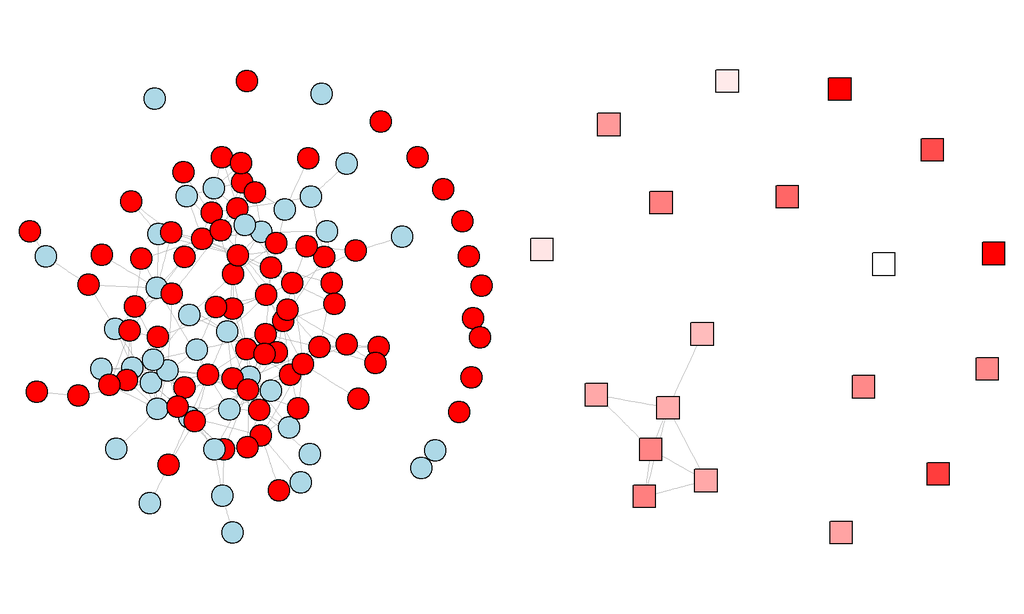

```r
par(mfrow = c(1, 2))
par(mar = c(0, 0, 0, 0))
plot(se_net_1, vertex.label = NA, vertex.size = 10,  vertex.frame.color = "black")
plot(se_net_2, vertex.label = NA, vertex.size = 10, vertex.frame.color = "black")
```

# A BIT MORE VISUALIZATION: animation

# An animated plot of the **Civil Rights** Egonet

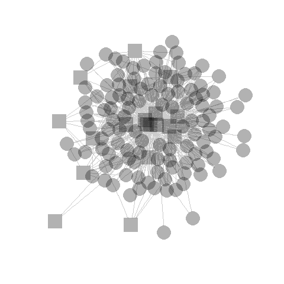

# CODE FOR PREVIOUS PLOT, PT 1

The `animation` package requires that your first install ImageMagick (imagemagick.org) software on your computer

```r
library('animation')

# Check that the package knows where to find ImageMagick
ani.options("convert")

# If it doesn't know where to find it, give it the correct path for your system
ani.options(convert = "C:/Program Files/ImageMagick-6.9.7-Q16/convert.exe")

# CHOOSE LAYOUT, COLORS, ETC
fr_coords <- layout.fruchterman.reingold(twomode_net) %>%
  norm_coords(ymin = -1, ymax = 1, xmin = -1, xmax = 1)
V(twomode_net)$color <- rgb(0, 0, 0, .3)
V(twomode_net)$frame.color <- NA
V(twomode_net)$label <- ""
E(twomode_net)$color <- "grey80"
```

# CODE FOR PREVIOUS PLOT, PT 2

```r
saveGIF( {
    col <- rep( rgb(0, 0, 0, .3), vcount(twomode_net))
    plot(twomode_net, vertex.color=col, rescale = FALSE, layout = fr_coords * 1.0 )

    step.1 <- V(twomode_net)[name == 2]
    col[step.1] <- "#ff5100"
    plot(twomode_net, vertex.color = col, rescale = FALSE, layout = fr_coords * 1.0 )

    step.2 <- unlist(neighborhood(twomode_net, 1, step.1))
    col[setdiff(step.2, step.1)] <- "#ff9d00"
    plot(twomode_net, vertex.color=col, rescale = FALSE, layout = fr_coords * 1.0 )

    step.3 <- delete_vertices(twomode_net, grep("#0000", col))
    plot(step.3, vertex.color=col[-grep("#0000", col)], rescale = FALSE,
         layout=fr_coords[-grep("#0000", col), ] * 1.0 )
  },
  interval = .8, movie.name = "network_animation.gif" )
```